# PCA on Parental HIV data

```r
options(width =800)
library(knitr); library(rmarkdown);library(ggplot2)
library(xtable); library(dplyr)
options(xtable.comment = FALSE)
opts_chunk$set(warning=FALSE, message=FALSE, fig.height=4, fig.width=5, fig.align='center')
```

## Goal: Use PCA to reduce the 25 parental bonding variables into a few components,

Then use those components in a regression model for overall BSI score.

```r
hiv  <- read.delim("C:/GitHub/MATH456/data/PARHIV_022216.txt")
parent <- select(hiv, PB01:PB25)
names(parent)
```

```
##  [1] "PB01" "PB02" "PB03" "PB04" "PB05" "PB06" "PB07" "PB08" "PB09" "PB10" "PB11" "PB12" "PB13" "PB14" "PB15" "PB16" "PB17" "PB18" "PB19" "PB20" "PB21" "PB22" "PB23" "PB24" "PB25"
```

Perform PCA using the correlation matrix. You can use the correlation or covariance matrix.

```r
pc_parent  <- princomp(parent, cor=TRUE)
```

```
## Error in cov.wt(z): 'x' must contain finite values only
```

Note the error. This is because of missing data. Find out the ID of the people who are missing data (i.e. do not have complete.cases)

```r
which(complete.cases(parent)==FALSE)
```

```
## [1] 154 180
```

and then remove them.

```r
parent <- parent[-c(154, 180),]
```

**Note!** This is very important to not simply do `na.omit()` here or otherwise remove the cases with missing data without figuring out *which rows* have the missing data. We will need this information later during regression modeling.

### Create a scree plot and interpret.

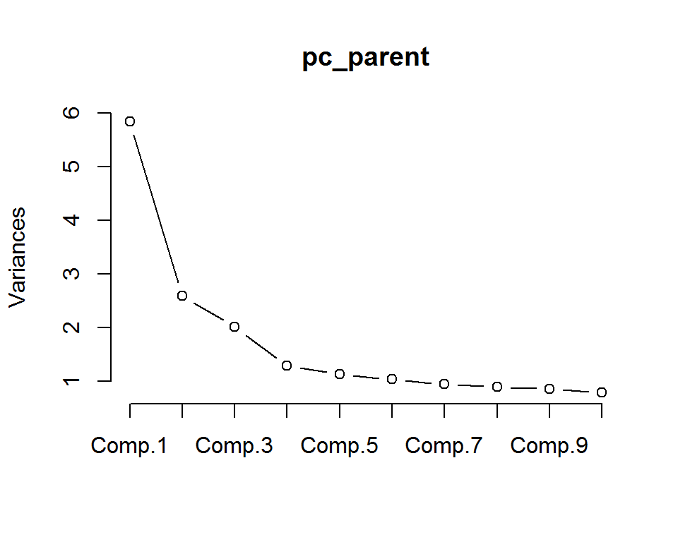

```r
pc_parent  <- princomp(parent, cor=TRUE)
screeplot(pc_parent, type='lines')
```

### Create a cumulative variance plot and interpret.

How much variance is explained by each PC?

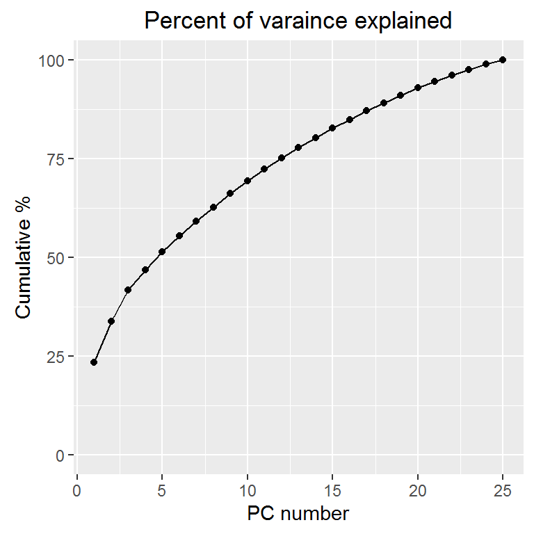

```r
qplot(x=1:NCOL(parent), y=cumsum(pc_parent$sdev^2)/sum(pc_parent$sdev^2)*100,
           geom=c("point", "line"), main="Percent of varaince explained") +
           xlab("PC number") + ylab("Cumulative %") +  ylim(c(0,100))
```

### Examine the factor loadings of the first $K$ PC’s.

You choose $K$ using the information above. I am using 10 as a demonstration, you will probably not use this many. The rule of thumb per section 14.5 is to select only the principal components that account for at least 100/P% of the total variance.

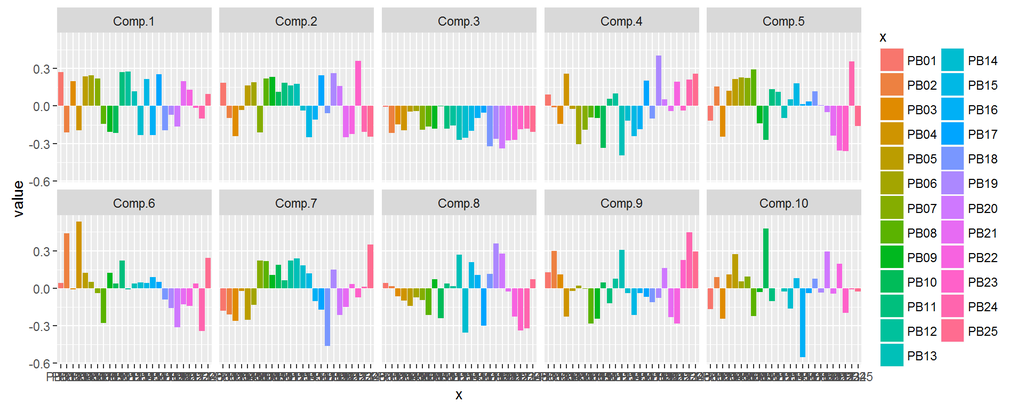

```r
library(reshape2)
load   <- data.frame(pc_parent$loadings[,1:10])
melted <- cbind(x=names(parent), melt(load))

ggplot(data=melted) +
  geom_bar(aes(x=x, y=value, fill=x), stat="identity") +
  facet_wrap(~variable, ncol=5)
```

# Model BSI

## Introduction

The Brief Symptom Inventory (BSI) is designed to assess recent psychological symptoms. The overall score (average of all components) is a measure of overall psychological distress level. For more info see: http://link.springer.com/referenceworkentry/10.1007%2F978-1-4419-1005-9_3

##### Review: Question Formulation: Data Analysis

When starting to conduct an analysis of some data, what are the first few things you want to know? What questions do you ask?

## Build a model for BSI

Use some demographic covariates (your choice, but justify why you chose them), along with the principal components you chose from the prior step.

1. Choose some predictor variables and make sure they are the correct variable type.

```r
model.data <- hiv[, c('HOOKEY', 'SCHOOL', 'ETHN', 'BSI_overall')]
str(model.data)
```

```
## 'data.frame':    252 obs. of  4 variables:
##  $ HOOKEY     : int  2 2 1 2 2 1 1 1 2 1 ...
##  $ SCHOOL     : int  2 2 2 2 2 2 2 2 2 2 ...
##  $ ETHN       : int  2 3 1 2 2 2 2 1 2 1 ...
##  $ BSI_overall: num  0.472 0.415 0 0.226 0.245 ...
```

```r
model.data$ETHN <- factor(model.data$ETHN, labels = c('Latino', 'Black', 'Other'))
model.data$HOOKEY <- factor(model.data$HOOKEY, labels = c('No', 'Yes'))
model.data$SCHOOL <- factor(model.data$SCHOOL, labels = c('No', 'Yes'))
```

2. Extract the fist $K$ component variables $C_{i}$ for each person.

```r
scores <- pc_parent$scores[,1:10]
head(scores)
```

```
##      Comp.1     Comp.2      Comp.3     Comp.4      Comp.5     Comp.6      Comp.7     Comp.8       Comp.9     Comp.10
## 1  2.545454 -0.3503668 -0.99269808  1.1551945 -0.08216192 -1.1999356 -0.03161238  0.4804276  0.467865727  0.67831458
## 2 -5.475620  3.1838127  0.07637725  0.4163661  1.19708846 -0.6000372 -1.11401114 -1.0320572 -0.005295999 -0.05637068
## 3  1.785791  1.2507101 -1.54738576 -1.0784027 -0.80971556  0.1560705 -0.13244097  0.8050737 -0.070568716 -1.18549829
## 4 -6.024210 -0.9639244  2.13581428  0.6428350 -1.58388510 -0.2659209  2.92931989 -0.3048967 -2.242340280  0.92839262
## 5  1.761024 -1.8684229  0.75402721 -0.7781030  0.17928042 -1.0067737 -0.12440845 -0.9213623  0.663808380  0.51356824
## 6 -2.174046  2.3703644 -0.96418446 -0.2769600 -0.36438592  2.7043645  1.70960755  0.7704263  1.255210442  0.78205020
```

3. Add these scores to the demographic data. This is where we needed to know who those two people with missing parental bonding data were.

```r
dim(model.data)
```

```
## [1] 252   4
```

```r
dim(scores)
```

```
## [1] 250  10
```

Remove them from the model data.

```r
model.data <- model.data[-c(154, 180),]
dim(model.data)
```

```
## [1] 250   4
```

Add the score data to the demographic data.

```r
mod.dta <- cbind(model.data, scores)
names(mod.dta)
```

```
##  [1] "HOOKEY"      "SCHOOL"      "ETHN"        "BSI_overall" "Comp.1"      "Comp.2"      "Comp.3"      "Comp.4"      "Comp.5"      "Comp.6"      "Comp.7"      "Comp.8"      "Comp.9"      "Comp.10"
```

4. Create a linear model of BSI. Refine as needed.

```r
model <- lm(BSI_overall ~ ., data=mod.dta)
summary(model)
```

```
##
## Call:
## lm(formula = BSI_overall ~ ., data = mod.dta)
##
## Residuals:
##     Min      1Q  Median      3Q     Max
## -0.9791 -0.3997 -0.1624  0.3288  2.6439
##
## Coefficients:
##               Estimate Std. Error t value Pr(>|t|)
## (Intercept)  0.7831251  0.1268864   6.172 2.98e-09 ***
## HOOKEYYes    0.0437942  0.0852614   0.514 0.607988
## SCHOOLYes   -0.1474837  0.1156915  -1.275 0.203655
## ETHNBlack   -0.0827057  0.0840232  -0.984 0.325984
## ETHNOther   -0.0027298  0.1205808  -0.023 0.981958
## Comp.1      -0.0567631  0.0157277  -3.609 0.000376 ***
## Comp.2       0.0195566  0.0241740   0.809 0.419348
## Comp.3       0.0154407  0.0269219   0.574 0.566838
## Comp.4       0.0028865  0.0343692   0.084 0.933141
## Comp.5      -0.0123282  0.0361293  -0.341 0.733244
## Comp.6      -0.0003819  0.0374944  -0.010 0.991882
## Comp.7       0.0570489  0.0395076   1.444 0.150088
## Comp.8      -0.0178747  0.0412261  -0.434 0.664999
## Comp.9       0.0522539  0.0412595   1.266 0.206615
## Comp.10     -0.0926114  0.0429387  -2.157 0.032047 *
## ---
## Signif. codes:  0 '***' 0.001 '**' 0.01 '*' 0.05 '.' 0.1 ' ' 1
##
## Residual standard error: 0.5947 on 232 degrees of freedom
##   (3 observations deleted due to missingness)
## Multiple R-squared:  0.1045, Adjusted R-squared:  0.05045
## F-statistic: 1.934 on 14 and 232 DF,  p-value: 0.024
```

Ethnicity does not look significant, but since there are multiple levels a deviance test needs to be checked.

```r
reduced <- lm(BSI_overall ~ .,  data=mod.dta[,-3])
anova(model, reduced)
```

```
## Analysis of Variance Table
##
## Model 1: BSI_overall ~ HOOKEY + SCHOOL + ETHN + Comp.1 + Comp.2 + Comp.3 +
##     Comp.4 + Comp.5 + Comp.6 + Comp.7 + Comp.8 + Comp.9 + Comp.10
## Model 2: BSI_overall ~ HOOKEY + SCHOOL + Comp.1 + Comp.2 + Comp.3 + Comp.4 +
##     Comp.5 + Comp.6 + Comp.7 + Comp.8 + Comp.9 + Comp.10
##   Res.Df    RSS Df Sum of Sq      F Pr(>F)
## 1    232 82.045
## 2    234 82.420 -2  -0.37562 0.5311 0.5887
```

This Likelihood ratio test indicates that there is no difference in the amount of the variance in `BSI_overall` explained by the model with and without ethnicity, so it will be dropped.

```r
summary(reduced)
```

```
##
## Call:
## lm(formula = BSI_overall ~ ., data = mod.dta[, -3])
##
## Residuals:
##     Min      1Q  Median      3Q     Max
## -0.9445 -0.4003 -0.1540  0.3268  2.6640
##
## Coefficients:
##              Estimate Std. Error t value Pr(>|t|)
## (Intercept)  0.764141   0.124162   6.154 3.24e-09 ***
## HOOKEYYes    0.034479   0.084410   0.408 0.683303
## SCHOOLYes   -0.155571   0.115066  -1.352 0.177674
## Comp.1      -0.056189   0.015676  -3.584 0.000411 ***
## Comp.2       0.019590   0.024114   0.812 0.417407
## Comp.3       0.012397   0.026652   0.465 0.642255
## Comp.4       0.004139   0.034057   0.122 0.903381
## Comp.5      -0.010603   0.035988  -0.295 0.768532
## Comp.6      -0.001411   0.037400  -0.038 0.969945
## Comp.7       0.057525   0.039415   1.459 0.145784
## Comp.8      -0.014862   0.041040  -0.362 0.717577
## Comp.9       0.053327   0.041128   1.297 0.196037
## Comp.10     -0.093808   0.042655  -2.199 0.028840 *
## ---
## Signif. codes:  0 '***' 0.001 '**' 0.01 '*' 0.05 '.' 0.1 ' ' 1
##
## Residual standard error: 0.5935 on 234 degrees of freedom
##   (3 observations deleted due to missingness)
## Multiple R-squared:  0.1004, Adjusted R-squared:  0.05426
## F-statistic: 2.176 on 12 and 234 DF,  p-value: 0.01356
```

Furthermore, it looks like PC’s 2 through 9 are non-significant predictors of the outcome. This would be a good time to consider conducting an automated variable selection procedure on the remaining variables. **This is not always necessary**